# [지상파 편법 중간광고 4년간 43배 ‘폭증’... 방통위는 수수방관](https://biz.chosun.com/site/data/html_dir/2020/09/21/2020092100621.html)

[figure not shown]

> 현행 법은 지상파 중간광고를 허용하지 않는다. 하지만 방송사들이 프로그램을 1, 2부로 쪼개 그 사이에 광고를 넣는 사실상의 중간광고를 시행하고 있지만 이에 대한 규제가 없어 ‘꼼수’ 중간광고가 증가한 것으로 해석된다. 출처 : 미디어오늘(http://www.mediatoday.co.kr)

[figure not shown]

위 그래프에서 확인할 수 있듯이,  
디지털 모바일 광고시장이 급격하게 커지면서 지상파 방송국은 2017년부터 본격적으로 PCM('꼼수' 중간광고)을 도입하였습니다.  
그 결과, 엄청난 광고수익(5년간 3000억원)을 얻고 있습니다. PCM 도입으로 방송국은 돈을 벌어 싱글벙글하고 있는 상황입니다.

그에 반해 시청자 입장은 어떨까요?

[figure not shown]

1시간 짜리 드라마를 2~3번씩 쪼개어 중간에 광고를 시청하고 있는 시청자는 기분이 안좋을 수 밖에 없습니다.  
"광고를 보는 건지 드라마를 보는건지 모르겠다" 같은 반응을 보일 정도로 말이죠.!!  
방송국에 불만을 가진 시청자들이 계속 드라마를 시청할까요? 채널을 돌리거나 유튜브 보러 떠나지 않을까요?

**이런 제 생각이 맞는지 데이터를 통해 알아보려고 합니다.**

## 아래의 데이터를 이용하여 분석을 진행하였습니다.

|  | KBS | MBC | SBS | EBS |
| --- | --- | --- | --- | --- |
| 2016 | 1 | 1 | 0 | 0 |
| 2017 | 4 | 5 | 7 | 0 |
| 2018 | 12 | 7 | 8 | 0 |
| 2019 | 26 | 19 | 23 | 5 |

- 2016 ~ 2019년 방송사별 PCM 데이터입니다.

|  | 방송사 | 방송년도 | 평균시청률 |
| --- | --- | --- | --- |
| 0 | KBS | 2016 | 9.242737 |
| 1 | KBS | 2017 | 6.712579 |
| 2 | KBS | 2018 | 4.493728 |
| 3 | KBS | 2019 | 5.968672 |
| 4 | MBC | 2016 | 7.943200 |
| 5 | MBC | 2017 | 7.203440 |
| 6 | MBC | 2018 | 4.443243 |
| 7 | MBC | 2019 | 3.996528 |
| 8 | SBS | 2016 | 11.237419 |
| 9 | SBS | 2017 | 11.657917 |
| 10 | SBS | 2018 | 6.377667 |
| 11 | SBS | 2019 | 6.107639 |

- 2016 ~ 2019년 방송사별 드라마 시청률 데이터입니다.

## 가설을 확인해보았습니다.

가설 : PCM이 증가할수록 드라마의 시청률은 떨어질 것이다.

### 채널별로 PCM 증가에 따라 평균시청률이 어떻게 변하는지 알아보았습니다.

#### KBS

|  | 방송사 | 방송년도 | 평균시청률 | PCM |
| --- | --- | --- | --- | --- |
| 0 | KBS | 2016 | 9.242737 | 1 |
| 1 | KBS | 2017 | 6.712579 | 4 |
| 2 | KBS | 2018 | 4.493728 | 12 |
| 3 | KBS | 2019 | 5.968672 | 26 |

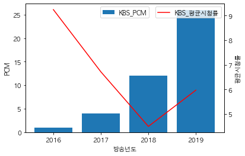

KBS의 경우 PCM의 꾸준한 상승과 함께 전반적으로 평균시청률이 하락하였습니다.  
하지만 2019년 평균시청률이 상승하였다. 동백꽃 필 무렵, 왜그래 풍상씨 등 대박드라마의 영향으로 추측할 수 있습니다.

#### MBC

|  | 방송사 | 방송년도 | 평균시청률 | PCM |
| --- | --- | --- | --- | --- |
| 0 | MBC | 2016 | 7.943200 | 1 |
| 1 | MBC | 2017 | 7.203440 | 5 |
| 2 | MBC | 2018 | 4.443243 | 7 |
| 3 | MBC | 2019 | 3.996528 | 19 |

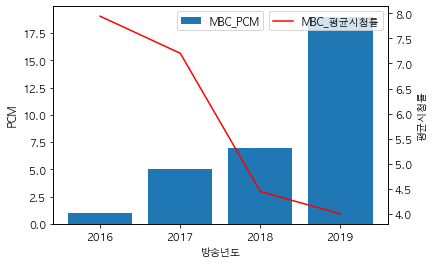

MBC의 경우 연도에 따라 꾸준한 PCM의 증가와 평균시청률의 하락을 보이고 있습니다.

#### SBS

|  | 방송사 | 방송년도 | 평균시청률 | PCM |
| --- | --- | --- | --- | --- |
| 0 | SBS | 2016 | 11.237419 | 0 |
| 1 | SBS | 2017 | 11.657917 | 7 |
| 2 | SBS | 2018 | 6.377667 | 8 |
| 3 | SBS | 2019 | 6.107639 | 23 |

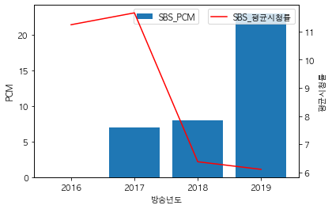

SBS의 경우 PCM을 처음 도입한 2017년 시청률 상승을 보였고 2018년에 시청률의 급격한 감소를 보였습니다.

### 방송사 구분없이 PCM 증가에 따라 평균시청률이 어떻게 변하는지 알아보았습니다.

[output not shown]

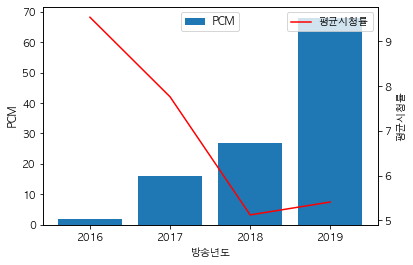

방송사 구분없이 PCM 개수에 따른 평균시청률 변화를 알아보았습니다.  
PCM 증가에 따라, 2016 ~ 2018년 까지 평균시청률은 급격하게 감소하였습니다.  
2019년, 폭발적으로 PCM 증가로 인해 시청률 감소를 예상했으나 시청률은 조금 상승하였습니다.  
앞서 살펴본 KBS채널에 대박드라마 탄생으로 평균시청률의 상승으로 인해 생긴 결과인 것으로 보여집니다.

## 결론

확인결과, 지상파 방송사가 본격적으로 PCM을 도입한 2017년부터 시청률이 급격하게 감소하였습니다.  
이는 PCM에 대한 불만이 시청자의 채널 이탈과 상관이 있다고 보여집니다.

모바일 광고 시장이 커지면서 방송사 광고 수익이 급감한 상황에서 어쩔 수 없는 선택임이 이해가지 않는 건 아니지만, 근시안적인 대처가 아닐까? 라는 의문이 생깁니다.  
섣부른 대처로 현재는 엄청난 광고수익을 얻고 있지만 그 대가로 시청자를 잃고 있으니깐요.  
결국 시청자를 잃은 방송사에게 어느 기업도 광고를 맡기지 않을 것이고, 시청자와 광고를 모든 잃은 방송사는 엄청난 손해가 발생함이 눈에 훤히 보입니다.

방송사들은 이러한 사실을 알고 시청자와 방송사가 win-win 할 수 있는 방안을 찾아야 합니다.  
시청률 바닥이 얼마 남지 않았습니다. 방송사 관계자 여러분 눈을 얼른 뜨시죠!